#### Projet élaboré par : The Mean Squares

# LAB 2 - Police d'assurances sur caravane

# Introduction

**AssurExperts** est une compagnie d'assurance canadienne qui veut savoir quelle population parmi sa clientèle, serait intéressée par une assurance caravane. Suite à une compagne de mailing, elle met à notre disposition un dataset comportant plusieurs variables,"socio-demographiques" et "propriétaire de produit".  
Le travail à faire consiste à classer ces clients en fonction de leur degrés d'appetence pour l'achat de cette assurance caravane, sachant que Assur Experts veut cibler la moitié de sa clientelle. Il faudra alors determiner, qui parmi ceux qui on répondu positivement à la compagne de mailing ont le profil d'un détenteur d'assurance caravane et qui parmi ceux qui ont répondu défavorablement ont un comportement similaire à un détenteur de cette assurance afin que le service marketing investisse dans le fait d'essayer de les convaincre de changer d'avis.

# Data Visualization

Dans cette première partie, nous visons à comprendre quelques aspects des donnèes qu'on posséde afin de pouvoir tirer des conclusions et des règles.

## Lecture des jeux de donnèes

Afin de pouvoir proposer des graphiques clairs et significatifs, il s'avère primordial de changer les noms des colonnes et le modalités codées de la plupart des colonnes.  
Dans cette optique, nous avons crée des jeux des donnés additionnelles qui faciliteront la tâche de la préparation data.  
Donc, hormis le fichier **AssurancExpertsInc.txt**, nous allons importer les fichiers **L0, L1, L2 et desc**.

- L0 contient les modalitès de la colonne 1
- L1 contient les modalitès de la colonne 4
- L2 contient les modalitès de la colonne 5
- Desc est une fichier qui contient les noms des colonnes ( codés et réels ).

```python
# This Python 3 environment comes with many helpful analytics libraries installed
# It is defined by the kaggle/python docker image: https://github.com/kaggle/docker-python
# For example, here's several helpful packages to load in

import numpy as np
import pandas as pd
import matplotlib.pyplot as plt
import seaborn as sns
%matplotlib inline

df = pd.read_table('AssurancExpertsInc.txt',sep = "\t")
desc = pd.read_table('desc.txt',sep = "\t")
```

```python
L0 = pd.read_table('L0.csv',sep = "\t")
L1 = pd.read_table('L1.csv',sep = "\t")
L2 = pd.read_table('L2.csv',sep = "\t")
```

Commençons par changer les noms des colonnes.

```python
df = df.drop(['STATUS'],axis = 1)
desc['Description'][85] = "CLASS"
df.columns = desc['Description']
```

## Corrélation entre les variables

Dans cette partie, nous allons tenter de minimiser la taille des données en supprimant les données qui proposent la même information et ce en trouvant une corrélation forte négative ou positive.  
Pour avoir un graphe plus lisible, nous allons étudier la corrélation des facteurs socio-démographiques à part.

### Corrélation entre les variables socio-démographiques

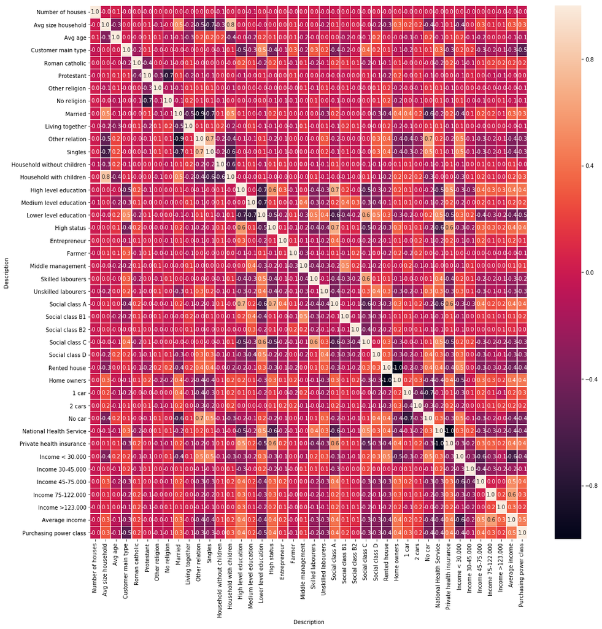

```python
f,ax = plt.subplots(figsize=(18, 18))
sns.heatmap(df[df.columns[1:43]].corr(), annot=True, linewidths=.5, fmt= '.1f',ax=ax)
```

Le graphe précédent ne reflète pas une corrélation importante. Néanmoins, nous pouvons remarquer que :

- La variable **Singles** est corrélée avec la variable **Other relation**
- La variable **Married** est aussi corrélée avec la variable **Other relation**
- La variable **Private Health Service** est *fortement* corrélée avec la variable **National Health Service**
- La variable **Lower Level Education** est corrélée avec les variables **Medium Level Education** et **High Level Education**
- La variable **Rented House** est complètement corrélée avec **Home Owners**

Donc nous pouvons supprimer les colonnes **Private Health Service** et **Rented House**

```python
df = df.drop(['Private health insurance','Rented house'],axis = 1)
```

### Corrélation entre les variables propriétaires de produit

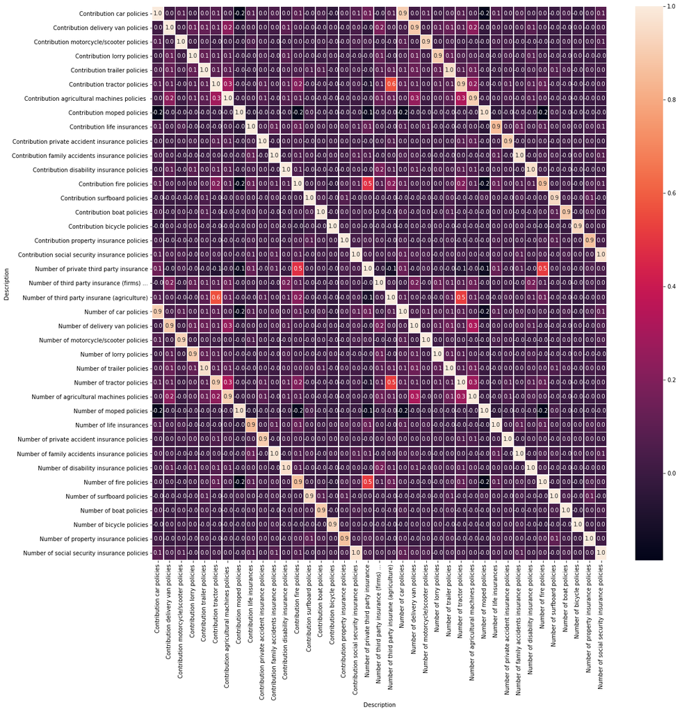

```python
f,ax = plt.subplots(figsize=(18, 18))
sns.heatmap(df[df.columns[44:85]].corr(), annot=True, linewidths=.5, fmt= '.1f',ax=ax)
```

La sortie de cette map de corrélation est hyper-importante : chaque contribution est fortement corréllée au nombre des assurances achetées de ce type.  
De ce fait, nous pouvons fusionner chaque contribution avec le nombre des assurances qui en est lié directement. En d'autres termes, nous pouvons procéder à la suppression des variables des contributions.

```python
df = df.drop(df.columns[41:61],axis = 1)
df1 = df.copy()
```

Ensuite, nous voulons changer les modalités propres à quelques variables :

```python
for i in range(len(df)):
    df.iloc[i,0] = L0.iloc[df.iloc[i,0]-1,2]
    df.iloc[i,3] = L1.iloc[df.iloc[i,3]-1,1]
    df.iloc[i,4] = L2.iloc[df.iloc[i,4]-1,1]
df.head()
```

| Description | Customer Subtype | Number of houses | Avg size household | Avg age | Customer main type | Roman catholic | Protestant | Other religion | No religion | Married | ... | Number of private accident insurance policies | Number of family accidents insurance policies | Number of disability insurance policies | Number of fire policies | Number of surfboard policies | Number of boat policies | Number of bicycle policies | Number of property insurance policies | Number of social security insurance policies | CLASS |
| --- | --- | --- | --- | --- | --- | --- | --- | --- | --- | --- | --- | --- | --- | --- | --- | --- | --- | --- | --- | --- | --- |
| 0 | Lower class large families | 1 | 3 | 30-40 years | Family with grown ups | 0 | 5 | 1 | 3 | 7 | ... | 0 | 0 | 0 | 1 | 0 | 0 | 0 | 0 | 0 | No |
| 1 | Mixed small town dwellers | 1 | 2 | 30-40 years | Family with grown ups | 1 | 4 | 1 | 4 | 6 | ... | 0 | 0 | 0 | 1 | 0 | 0 | 0 | 0 | 0 | No |
| 2 | Mixed small town dwellers | 1 | 2 | 30-40 years | Family with grown ups | 0 | 4 | 2 | 4 | 3 | ... | 0 | 0 | 0 | 1 | 0 | 0 | 0 | 0 | 0 | No |
| 3 | Modern, complete families | 1 | 3 | 40-50 years | Average Family | 2 | 3 | 2 | 4 | 5 | ... | 0 | 0 | 0 | 1 | 0 | 0 | 0 | 0 | 0 | No |
| 4 | Large family farms | 1 | 4 | 30-40 years | Farmers | 1 | 4 | 1 | 4 | 7 | ... | 0 | 0 | 0 | 1 | 0 | 0 | 0 | 0 | 0 | No |

5 rows × 64 columns

## Relation entre classe et les autres variables

Dans cette partie, nous allons essayer de caractériser les profils des clients par classe ( Yes / No ) par rapport au autres variables.  
Pour commencer, nous devons comparer la population **Yes** et la population **No**

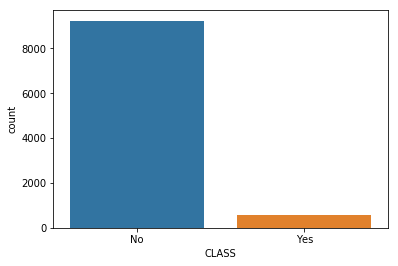

```python
sns.countplot(df['CLASS'])
```

Il est clair que les données sont pas balancées entre les classes.  
Par conséquant, les graphes qui comparent les deux classes par rapport à une variable quelconque ne seront pas utiles et interprétables. Nous allons donc plutôt présenter chaque variable par rapport à chaque classe à part.

Dans cette optique, il est plus simple de diviser note dataframe en deux ( un dataframe pour chaque classe )

```python
yes = df.loc[df['CLASS'] == 'Yes',:]
no = df.loc[df['CLASS'] == 'No',:]
```

### Principaux types des clients positifs

Puisque les données sont pas équilibrées, il est plus intelligent de plotter les pourcentages d'une variable par rapport au classe, et pas le nombre d'occurences.

1. Le code ci-dessous permet d'appliquer ceci.

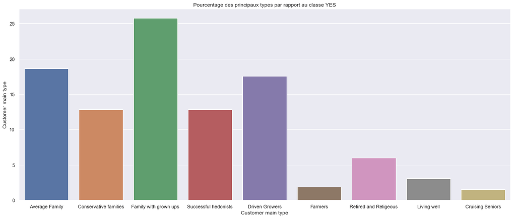

```python
plt.figure(figsize=(20,8),)
sns.set(style="darkgrid")
ax = sns.barplot(x="Customer main type",orient="v", y="Customer main type", data = yes, estimator=lambda x: len(x) / len(yes) * 100).set_title("Pourcentage des principaux types par rapport au classe YES")
```

### Principaux types des clients négatifs

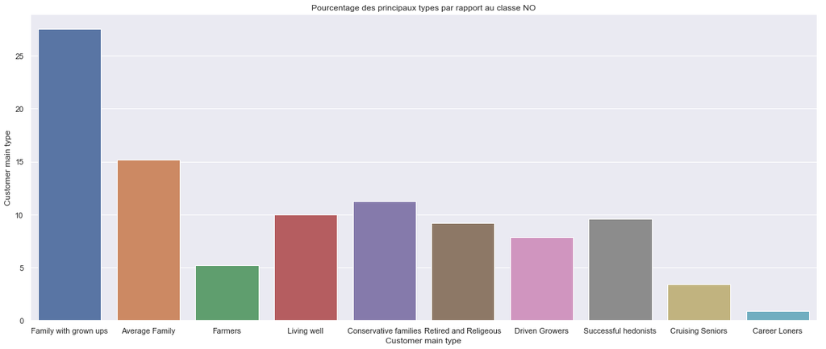

```python
plt.figure(figsize=(20,8))
sns.set(style="darkgrid")
ax = sns.barplot(x="Customer main type",orient="v", y="Customer main type", data = no, estimator=lambda x: len(x) / len(no) * 100).set_title("Pourcentage des principaux types par rapport au classe NO")
```

On peut remarquer en comparant les deux graphiques, que le type **Career Loners** appartient totalement à la classe négative. On constate aussi que le type **Family with grown ups** est le plus occurent dans le dataset.

### Age moyen par classe

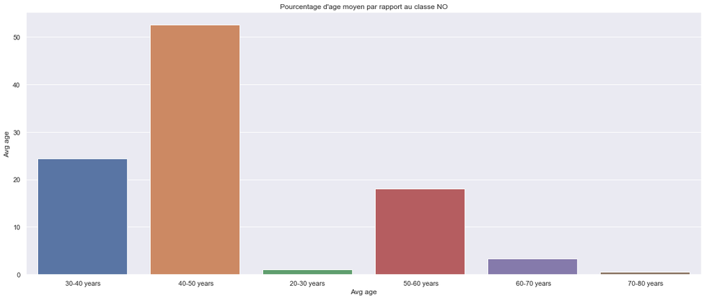

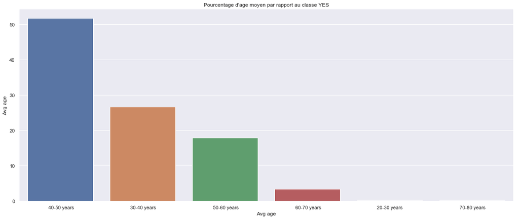

```python
plt.figure(figsize=(20,8))
sns.set(style="darkgrid")
ax1 = sns.barplot(x="Avg age",orient="v", y="Avg age", data = no, estimator=lambda x: len(x) / len(no) * 100).set_title("Pourcentage d'age moyen par rapport au classe NO")
plt.figure(figsize=(20,8))
sns.set(style="darkgrid")
ax2 = sns.barplot(x="Avg age",orient="v", y="Avg age", data = yes, estimator=lambda x: len(x) / len(yes) * 100).set_title("Pourcentage d'age moyen par rapport au classe YES")
```

D'après les deux graphiques ci-dessus, on peut constater que la variable **Avg Age** ne varie presque pas entre les deux classes.  
Cette variable peut être éliminée lors de la modélisation puisqu'elle ne propose pas d'informations.

### Sous-types des clients par classe

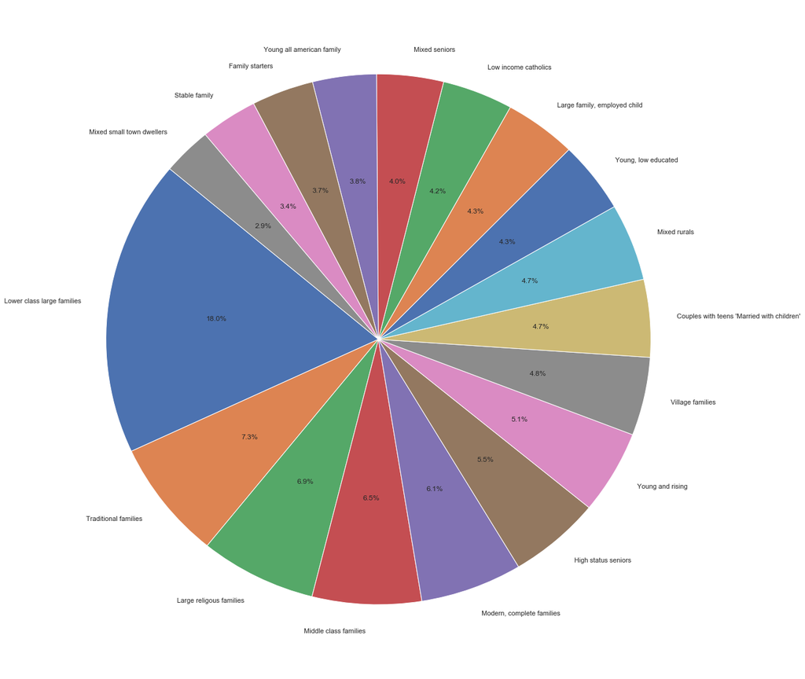

```python
plt.figure(figsize=(20,20))
plt.pie(no['Customer Subtype'].value_counts()[no['Customer Subtype'].value_counts() > 200], labels=no['Customer Subtype'].value_counts()[no['Customer Subtype'].value_counts() > 200].index,autopct='%1.1f%%', startangle=140);
```

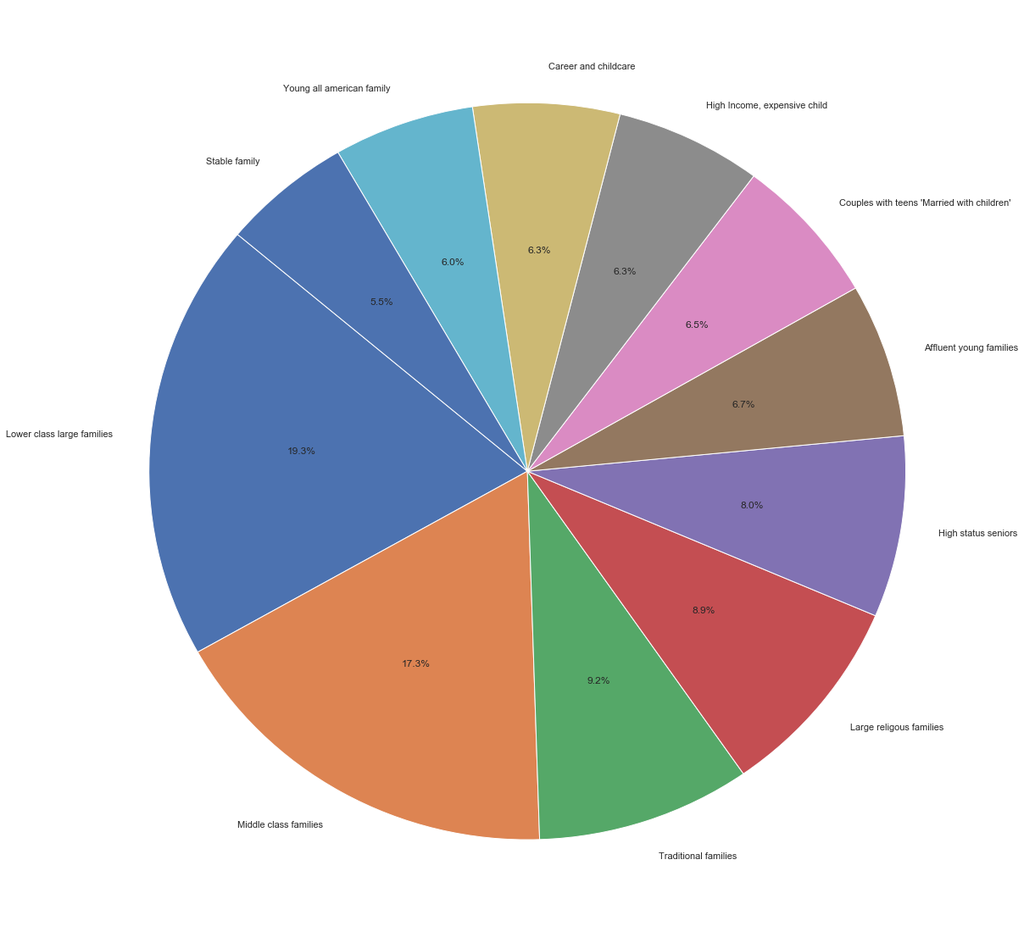

```python
plt.figure(figsize=(20,20))
plt.pie(yes['Customer Subtype'].value_counts()[yes['Customer Subtype'].value_counts() > 20], labels=yes['Customer Subtype'].value_counts()[yes['Customer Subtype'].value_counts() > 20].index,autopct='%1.1f%%', startangle=140);
```

### Analyse des composantes principales

Le but de cette partie est de réduire le nombre des colonnes à interpréter en un minimum de dimensions qui maximisent l'information. Nous allons appliquer l'analyse des composantes principales avec 3 axes.

```python
df1 = df1.drop(['Contribution social security insurance policies'],axis = 1)
```

On commence par séparer les variables sociodémographiques et le variables produits.

```python
df1_socio = df1.iloc[:,0:40]
df1_prod = df1.iloc[:,41:61]
```

### Variables sociodémographiques - ACP

```python
from sklearn.decomposition import PCA
pca = PCA()
pca.fit(df1_socio)
```

```
PCA(copy=True, iterated_power='auto', n_components=None, random_state=None,
  svd_solver='auto', tol=0.0, whiten=False)
```

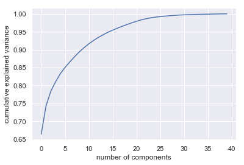

```python
plt.plot(np.cumsum(pca.explained_variance_ratio_))
plt.xlabel('number of components')
plt.ylabel('cumulative explained variance');
```

```python
pca = PCA(3)
pca.fit(df1_socio)
pca.explained_variance_ratio_.sum()
```

```
0.7836092581919635
```

Les 3 axes résument 78% de l'information.

### Variables des produits - ACP

```python
from sklearn.decomposition import PCA
pca1 = PCA()
pca1.fit(df1_prod)
```

```
PCA(copy=True, iterated_power='auto', n_components=None, random_state=None,
  svd_solver='auto', tol=0.0, whiten=False)
```

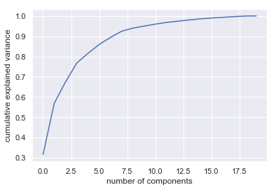

```python
plt.plot(np.cumsum(pca1.explained_variance_ratio_))
plt.xlabel('number of components')
plt.ylabel('cumulative explained variance');
```

```python
pca1 = PCA(5)
pca1.fit(df1_prod)
pca1.explained_variance_ratio_.sum()
```

```
0.8151705748314246
```

```python
df2 = df1.copy()
df2 = df2[["Customer Subtype","Number of car policies","Number of moped policies","Number of life insurances","CLASS"]]
```

```python
test=pd.DataFrame(pca.fit_transform(df1_socio))
test.head()
```

|  | 0 | 1 | 2 |
| --- | --- | --- | --- |
| 0 | -9.281560 | -3.666197 | -4.308307 |
| 1 | -12.338346 | -3.880362 | 1.499716 |
| 2 | -13.058697 | 4.138402 | 3.321478 |
| 3 | 15.908327 | 0.782854 | -0.557265 |
| 4 | -14.041245 | -9.223638 | 8.537012 |

```python
test= pd.DataFrame({'PCA1':test.iloc[:,0],'PCA2':test.iloc[:,1],'PCA3':test.iloc[:,2]})
```

```python
test1=pd.DataFrame(pca1.fit_transform(df1_prod))
```

```python
test1= pd.DataFrame({'PCA4':test1.iloc[:,0],'PCA5':test1.iloc[:,1],'PCA6':test1.iloc[:,2],'PCA7':test1.iloc[:,3],'PCA8':test1.iloc[:,4]})
```

```python
test3 = pd.concat([test, test1], axis=1)
```

```python
test3.head()
```

|  | PCA1 | PCA2 | PCA3 | PCA4 | PCA5 | PCA6 | PCA7 | PCA8 |
| --- | --- | --- | --- | --- | --- | --- | --- | --- |
| 0 | -9.281560 | -3.666197 | -4.308307 | 0.247132 | 0.293512 | -0.387111 | 0.435673 | -0.111356 |
| 1 | -12.338346 | -3.880362 | 1.499716 | 0.962761 | -0.978166 | 0.366953 | -0.979025 | 0.087477 |
| 2 | -13.058697 | 4.138402 | 3.321478 | 0.819786 | 0.102662 | -0.060575 | -0.251113 | 0.006269 |
| 3 | 15.908327 | 0.782854 | -0.557265 | 0.247132 | 0.293512 | -0.387111 | 0.435673 | -0.111356 |
| 4 | -14.041245 | -9.223638 | 8.537012 | -0.182546 | -0.596467 | -0.286119 | 0.394546 | -0.147773 |

```python
import lightgbm as lgm
my_model = lgm.LGBMClassifier(objective='binary', class_weight='balanced')
X_dataset = df1.loc[:, df1.columns.values != "CLASS"]
y_dataset = df1.loc[:, df1.columns.values == "CLASS"]
my_model.fit(np.array(test3), y_dataset,verbose=False)
preds = my_model.predict_proba(np.array(test3))
preds = preds[:, 1]
df1["Score"] = preds
```

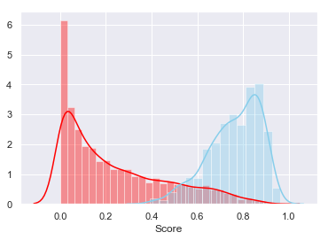

```python
sns.distplot( df1.loc[df1['CLASS'].values=="No",'Score'] , color="red", label="No")
sns.distplot( df1.loc[df1['CLASS'].values=="Yes",'Score'] , color="skyblue", label="Yes")
```

Nous observons la distributions des (Yes/No) par rapport aux scores.  
Ainsi, nous pouvons voir une logique dispersion de ceux qui ont répondu favorablement à l'achat d'une assurance caravane avec un fort score:

```python
df1.loc[df1['CLASS'].values=="Yes",'Score'].describe()
```

```
count    586.000000
mean       0.762702
std        0.114050
min        0.394427
25%        0.688956
50%        0.779189
75%        0.853285
max        0.963803
Name: Score, dtype: float64
```

De même, ceux qui ont répondu défavorablement ont un faible score:

```python
df1.loc[df1['CLASS'].values=="No",'Score'].describe()
```

```
count    9236.000000
mean        0.237516
std         0.224033
min         0.000153
25%         0.048576
50%         0.164059
75%         0.382849
max         0.931886
Name: Score, dtype: float64
```

Pour savoir la moitité de la clientelle active d'Assur Expert à cibler, il suffit de prendre la premiere moitié des clients triés de manière decroissante selon le score comme suit:

```python
df1_sorted = df1.sort_values(by='Score', ascending = False)
x = df1_sorted.iloc[0:int((len(df1_sorted)/2)-1),:]
```

[output not shown]

4910 rows × 64 columns

Donc dans notre cas les:

```python
len(df1_sorted.iloc[0:int((len(df1_sorted)/2)-1),:])
```

```
4910
```

Premiers.